# Projet - Sélection de modèle en régression linéaire

Université de Bordeaux - M1 Master MAS - UE : Modèles de régression

Année 2024-2025

**Nom : LE CAMUS**  
**Prénom : Arthur**

**Nom : DOSSOU**  
**Prénom : Félicia**

# Préambule

Dans ce projet, il est proposé de s’intéresser à l’analyse d’un jeu de données réelles disponible à l’URL : https://www.openlab.psu.edu/ansur2/.

Il s’agit du jeu de données `ANSUR II` (Anthropometric Survey of US Army Personnel) relatives à des caractéristiques de taille et forme du corps humain. Il s’agit d’un ensemble de 93 mesures effectuées sur plus de 6 000 militaires américains adultes, dont 4 082 hommes et 1 986 femmes. On va proposer de choisir la variable du **poids** et chercher à l’expliquer en fonction des $p=92$ autres variables du jeu de données à l’aide d’un modèle linéaire. Le but étant de trouver un sous-ensemble de variables qui permettent de bien expliquer le poids d’individu.

# Sommaire

### 1. Analyse descriptive

```
1.1 Prétraitement des données
1.2 Exploration initiale
1.3 Réduction de la dimension
1.4 Clustering des variables
1.5 Visualisation des relations
```

### 2. Sélection de modèle

```
2.1 Hommes
  2.1.1 Backward
    - Réduction initiale avec step
    - Génération de combinaisons de variables
    - Évaluation des critères
    - Résultats
    - Conclusion
  2.1.2 Forward
2.2 Femmes
  2.2.1 Backward
  2.2.2 Forward
```

# 1 / Analyse descriptive

## 1.1 Prétraitement des données

On charge les données anthropométriques ANSUR pour les hommes et les femmes, on sélectionne les variables explicatives, puis on isole le poids comme variable cible en la convertissant en kilogrammes.

```r
# Lecture des données ANSUR
ansurm = read.csv('ANSUR_II_MALE_Public.csv')
ansurf = read.csv('ANSUR_II_FEMALE_Public.csv')

p = 93 # Nombre de variables morphométriques
# names(ansurm)
# names(ansurf)

donnees_m = ansurm[2:(p+1)]
donnees_f = ansurf[2:(p+1)]
nom_variables = names(ansurm)[2:(p+1)]
print(nom_variables)

# Choix de la variable à expliquer
indices = 1:p
pos = indices[nom_variables == "weightkg"]
# pos = indices[nom_variables == "stature"]

Y_m = donnees_m[,pos]/10 # Conversion en kg
X_m = donnees_m[,-pos]
# dim(X_m)

Y_f = donnees_f[,pos]/10 # Conversion en kg
X_f = donnees_f[,-pos]
# dim(X_f)
```

## 1.2 Exploration initiale

La répartition du poids est étudiée à l’aide de courbes de densité pour les hommes et les femmes, permettant de comparer leurs distributions respectives.

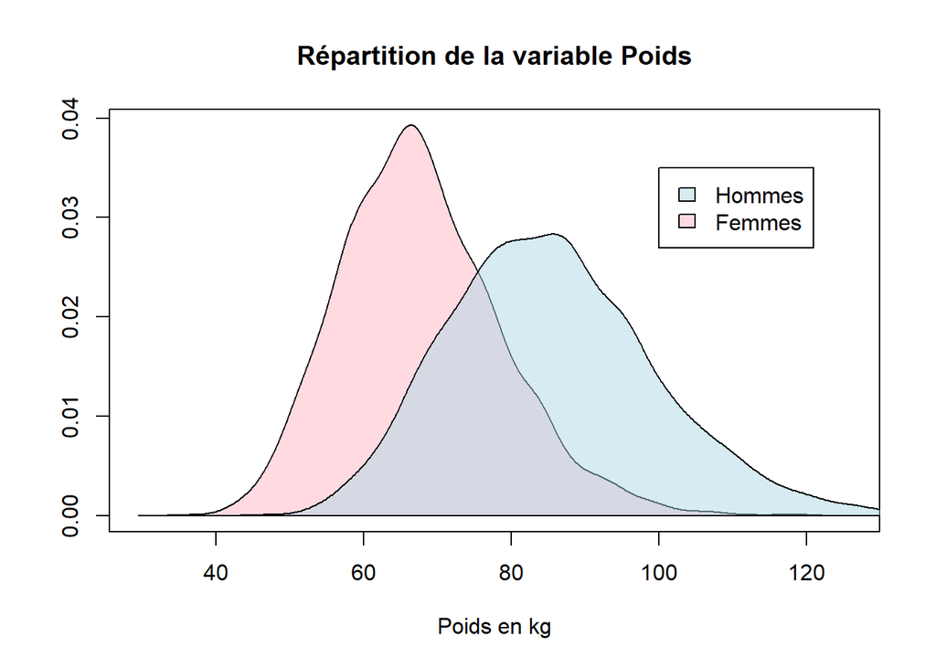

```r
# Visualisation de la répartition de la variable à expliquer selon le sexe
polycurve <- function(x, y, base.y = min(y), ...) {
  polygon(x = c(min(x), x, max(x)), y = c(base.y, y, base.y), ...)
}

colM = rgb(173/255, 216/255, 230/255, 0.5)
colF = rgb(255/255, 182/255, 193/255, 0.5)

res_f = density(Y_f)
plot(res_f$x,res_f$y,type="l",xlab="Poids en kg",ylab="")
polycurve(res_f$x, res_f$y, base.y = 0, col = colF)

res_m = density(Y_m)
lines(res_m$x,res_m$y,type="l")
polycurve(res_m$x, res_m$y, base.y = 0, col = colM)

legend(100, 0.035, legend=c("Hommes", "Femmes"),fill=c(colM, colF))
title('Répartition de la variable Poids')
```

## 1.3 Réduction de la dimension

On élimine les variables fortement corrélées entre elles (corrélation > 0.8) pour obtenir des matrices réduites (`X_m_reduced` et `X_f_reduced`).Pour chaque paire de variables fortement corrélées, on conserve celle ayant la plus forte corrélation avec le poids et on élimine l’autre. La dimension passe ainsi de 92 variables à 45 pour les hommes et 44 pour les femmes. Ce sont ces matrices qu’on utilisera pour la sélection de modèle.

```r
library(caret)

reduce_highly_correlated <- function(X, Y, threshold = 0.8) {
  cor_matrix <- cor(X)
  while (TRUE) {
    highly_correlated <- which(abs(cor_matrix) > threshold, arr.ind = TRUE)
    highly_correlated <- highly_correlated[highly_correlated[, 1] != highly_correlated[, 2], ]
    if (nrow(highly_correlated) == 0) break
    var1 <- rownames(cor_matrix)[highly_correlated[1, 1]]
    var2 <- rownames(cor_matrix)[highly_correlated[1, 2]]
    cor_var1 <- abs(cor(X[[var1]], Y))
    cor_var2 <- abs(cor(X[[var2]], Y))
    if (cor_var1 < cor_var2) {
      var_to_remove <- var1
    } else {
      var_to_remove <- var2
    }
    X <- X[, !(colnames(X) == var_to_remove)]
    cor_matrix <- cor(X)
  }
  return(X)
}

X_m_reduced <- reduce_highly_correlated(X_m, Y_m, threshold = 0.8)
X_f_reduced <- reduce_highly_correlated(X_f, Y_f, threshold = 0.8)

# dim(X_m_reduced)
# dim(X_f_reduced)
```

Nous réalisons une analyse en composantes principales (ACP) sur les données centrées des hommes et des femmes afin de calculer la variance expliquée par chaque composante et déterminer le nombre minimal de composantes nécessaires pour conserver 90 % de la variance.

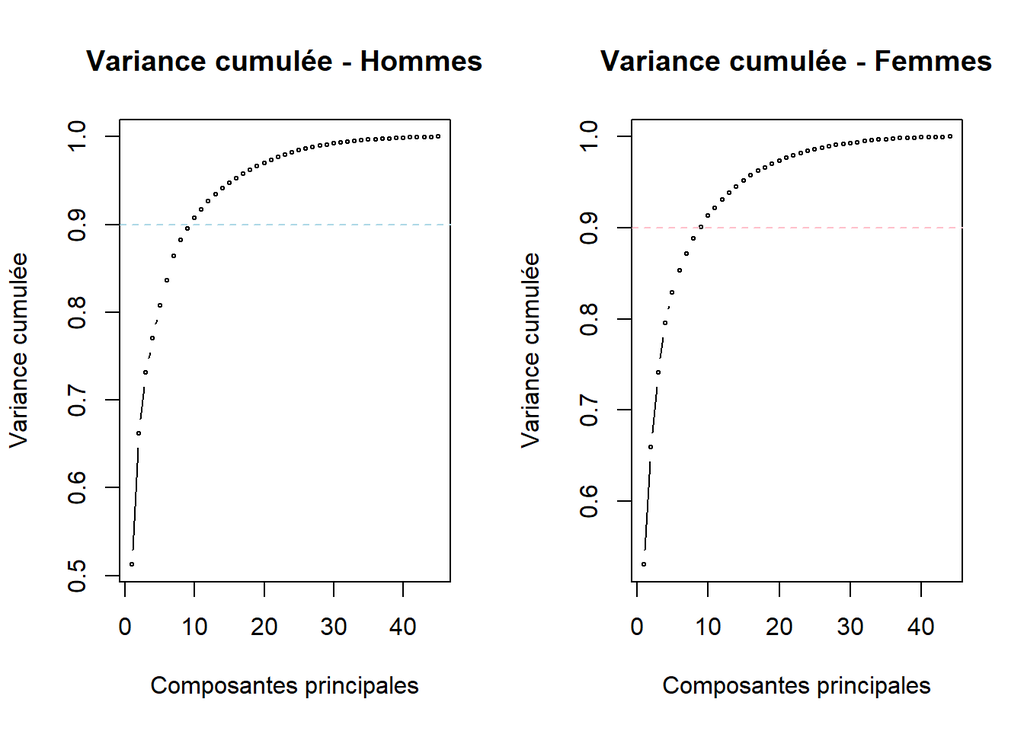

```r
# Centrage variables
X_m_centered <- scale(X_m_reduced, center = TRUE, scale = FALSE)
X_f_centered <- scale(X_f_reduced, center = TRUE, scale = FALSE)

#ACP
acp_m <- prcomp(X_m_centered, center = FALSE, scale. = FALSE)
acp_f <- prcomp(X_f_centered, center = FALSE, scale. = FALSE)

# Calcul de la variance expliquée puis cumulée
variance_expliquee_m <- acp_m$sdev^2 / sum(acp_m$sdev^2)
variance_expliquee_f <- acp_f$sdev^2 / sum(acp_f$sdev^2)
variance_cumulee_m <- cumsum(variance_expliquee_m)
variance_cumulee_f <- cumsum(variance_expliquee_f)

# k tel qu'on préserve 90% de la variance
k_m <- which(variance_cumulee_m >= 0.90)[1]
k_f <- which(variance_cumulee_f >= 0.90)[1]

par(mfrow = c(1, 2))
# Graph des hommes
plot(variance_cumulee_m, type = "b", pch = 1,cex = 0.4,  main = "Variance cumulée - Hommes",
     xlab = "Composantes principales", ylab = "Variance cumulée")
abline(h = 0.90, col = "lightblue", lty = 2)
# Graph des femmes
plot(variance_cumulee_f, type = "b",pch = 1,cex = 0.4, main = "Variance cumulée - Femmes",
     xlab = "Composantes principales", ylab = "Variance cumulée")
abline(h = 0.90, col = "pink", lty = 2)
```

```r
# print(k_m)
# print(k_f)
```

## 1.4 Clustering des variables

Nous regroupons les variables issues de l’ACP en clusters pour les hommes et les femmes en identifiant la composante principale qui représente le mieux chaque variable. Pour cela, nous calculons les distances de projection afin de prioriser les variables les mieux projetées dans le nouvel espace. Enfin, nous attribuons des noms significatifs à chaque cluster pour en faciliter l’interprétation.

```r
# Extraction coeff composantes principales
loadings_m <- acp_m$rotation[, 1:11]
loadings_f <- acp_f$rotation[, 1:11]

# Regroupements clusters
clusters_m <- apply(loadings_m, 1, function(row) which.max(abs(row)))
clusters_f <- apply(loadings_f, 1, function(row) which.max(abs(row)))
variables_clusters_m <- data.frame(Variable = colnames(X_m_centered), Cluster = clusters_m)
variables_clusters_f <- data.frame(Variable = colnames(X_f_centered), Cluster = clusters_f)

# Calcul des distances au centre
distances_m <- apply(loadings_m, 1, function(row) sqrt(sum(row^2)))
distances_f <- apply(loadings_f, 1, function(row) sqrt(sum(row^2)))
variables_clusters_m$Distance_Centre <- distances_m
variables_clusters_f$Distance_Centre <- distances_f

# variables_cluster_m
# variables_cluster_f

# Renommage clusters hommes
variables_clusters_m$ClusterName <- NA
variables_clusters_m$ClusterName[variables_clusters_m$Cluster == 1] <- "HauteurEtTaille"
variables_clusters_m$ClusterName[variables_clusters_m$Cluster == 2] <- "DimensionsDuCou"
variables_clusters_m$ClusterName[variables_clusters_m$Cluster == 3] <- "HauteurSiège"
variables_clusters_m$ClusterName[variables_clusters_m$Cluster == 4] <- "LongueurDuTronc"
variables_clusters_m$ClusterName[variables_clusters_m$Cluster == 5] <- "PortéeDesBras"
variables_clusters_m$ClusterName[variables_clusters_m$Cluster == 6] <- "LargeurDeLaTête"
variables_clusters_m$ClusterName[variables_clusters_m$Cluster == 7] <- "LargeurDesHanches"
variables_clusters_m$ClusterName[variables_clusters_m$Cluster == 8] <- "ProfondeurDeLAbdomen"
variables_clusters_m$ClusterName[variables_clusters_m$Cluster == 9] <- "LongueurDesBras"
variables_clusters_m$ClusterName[variables_clusters_m$Cluster == 10] <- "DimensionsDesPieds"
variables_clusters_m$ClusterName[variables_clusters_m$Cluster == 11] <- "LargeurDesÉpaules"

# Renommage clusters femmes
variables_clusters_f$ClusterName <- NA
variables_clusters_f$ClusterName[variables_clusters_f$Cluster == 1] <- "CirconférenceDuTronc"
variables_clusters_f$ClusterName[variables_clusters_f$Cluster == 2] <- "DimensionsThorax"
variables_clusters_f$ClusterName[variables_clusters_f$Cluster == 3] <- "HauteurDuSiège"
variables_clusters_f$ClusterName[variables_clusters_f$Cluster == 4] <- "LongueurDuBuste"
variables_clusters_f$ClusterName[variables_clusters_f$Cluster == 5] <- "PortéeDesBras"
variables_clusters_f$ClusterName[variables_clusters_f$Cluster == 6] <- "LargeurDeLaFace"
variables_clusters_f$ClusterName[variables_clusters_f$Cluster == 7] <- "LargeurDesÉpaules"
variables_clusters_f$ClusterName[variables_clusters_f$Cluster == 8] <- "TourDesBras"
variables_clusters_f$ClusterName[variables_clusters_f$Cluster == 9] <- "CirconférenceJambes"
variables_clusters_f$ClusterName[variables_clusters_f$Cluster == 10] <- "LargeurDesPieds"
variables_clusters_f$ClusterName[variables_clusters_f$Cluster == 11] <- "DimensionsDuCou"
```

## 1.5 Visualisation des relations

Les variables ont été regroupées par cluster, et leur moyenne a été calculée pour chaque ligne afin de créer un dataframe synthétique. Ce dataframe permet d’analyser les interactions entre clusters, notamment via une **matrice de corrélation**.

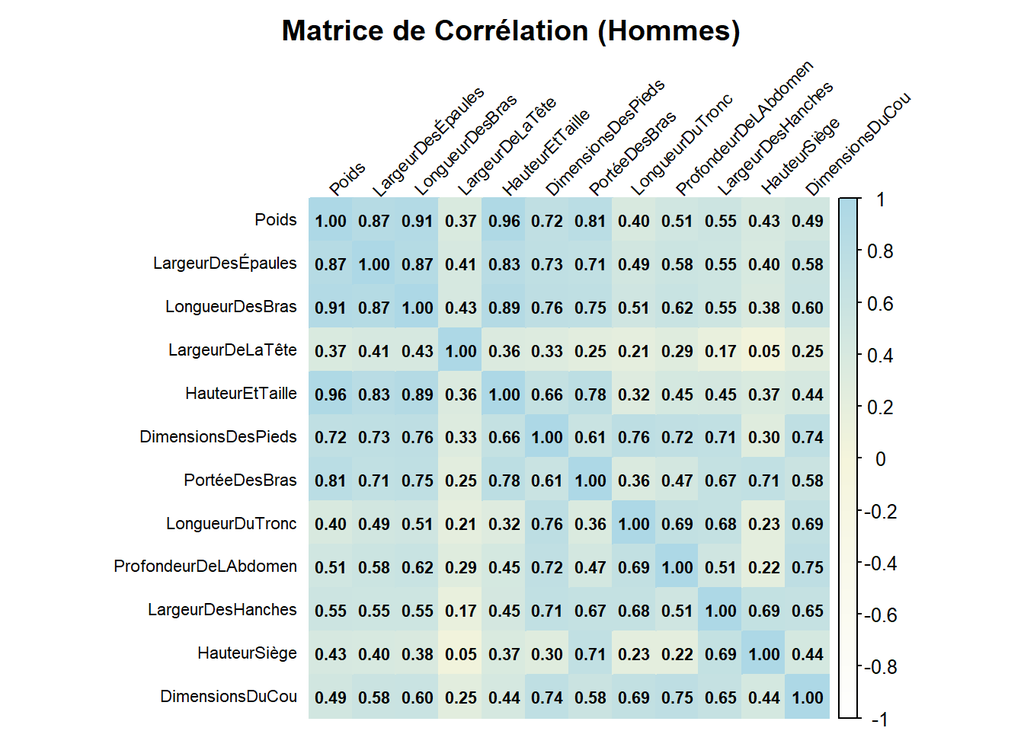

```r
library(corrplot)

# Création df synthétique
unique_clusters_m <- unique(variables_clusters_m$ClusterName)
synthetic_m <- as.data.frame(matrix(NA, nrow = nrow(X_m_reduced), ncol = length(unique_clusters_m)))
colnames(synthetic_m) <- unique_clusters_m

for (cluster_name in colnames(synthetic_m)) {
  variables_in_cluster <- variables_clusters_m$Variable[variables_clusters_m$ClusterName == cluster_name]
  if (all(variables_in_cluster %in% colnames(X_m_centered))) {
    synthetic_m[[cluster_name]] <- rowMeans(X_m_centered[, variables_in_cluster, drop = FALSE], na.rm = TRUE)
  } else {
    warning(paste("Erreur"))
  }
}

# Matrice de corrélation
correlation_matrix_m <- cor(cbind(Poids = Y_m, synthetic_m), use = "complete.obs")
corrplot(
  correlation_matrix_m,
  method = "color",
  col = colorRampPalette(c("white", "beige", "lightblue"))(200),
  title = "Matrice de Corrélation (Hommes)",
  addCoef.col = "black",
  tl.col = "black",
  tl.srt = 45,
  tl.cex = 0.7,
  cl.pos = "r",
  cl.cex = 0.8,
  number.cex = 0.7,
  mar = c(0, 0, 2, 0)
)
```

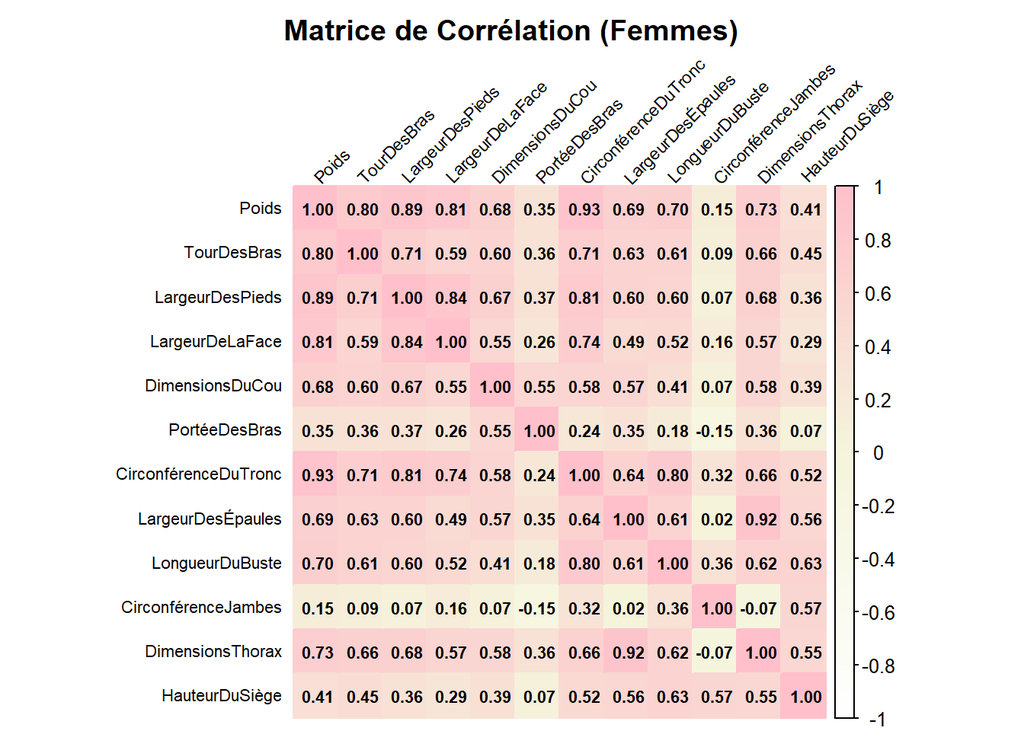

```r
unique_clusters_f <- unique(variables_clusters_f$ClusterName)
synthetic_f <- as.data.frame(matrix(NA, nrow = nrow(X_f_reduced), ncol = length(unique_clusters_f)))
colnames(synthetic_f) <- unique_clusters_f

for (cluster_name in colnames(synthetic_f)) {
  variables_in_cluster <- variables_clusters_f$Variable[variables_clusters_f$ClusterName == cluster_name]
  if (all(variables_in_cluster %in% colnames(X_f_centered))) {
    synthetic_f[[cluster_name]] <- rowMeans(X_f_centered[, variables_in_cluster, drop = FALSE], na.rm = TRUE)
  } else {
    warning(paste("Erreur"))
  }
}

# Matrice de corrélation
correlation_matrix_f <- cor(cbind(Poids = Y_f, synthetic_f), use = "complete.obs")
corrplot(
  correlation_matrix_f,
  method = "color",
  col = colorRampPalette(c("white", "beige", "pink"))(200),
  title = "Matrice de Corrélation (Femmes)",
  addCoef.col = "black",
  tl.col = "black",
  tl.srt = 45,
  tl.cex = 0.7,
  cl.pos = "r",
  cl.cex = 0.8,
  number.cex = 0.7,
  mar = c(0, 0, 2, 0)
)
```

Pour obtenir une visualisation plus détaillée de la relation entre chaque cluster synthétique et le poids , nous avons créé une grille de graphiques de scatter plots. Cela permet d’identifier des tendances spécifiques ou des outliers.

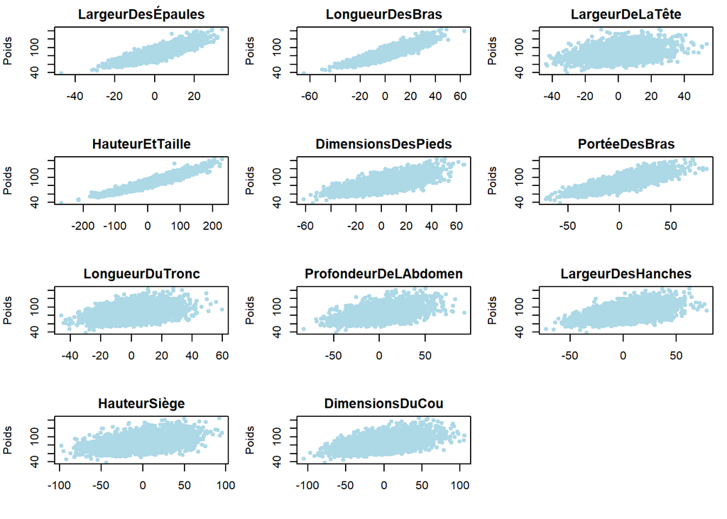

```r
# Hommes
par(mfrow = c(4, 3), mar = c(4, 4, 2, 1))
for (cluster_name in colnames(synthetic_m)) {
  plot(
    synthetic_m[[cluster_name]], Y_m,
    main = cluster_name,
    xlab = "",
    ylab = "Poids",
    col = "lightblue", pch = 19, cex = 0.7
  )
}
```

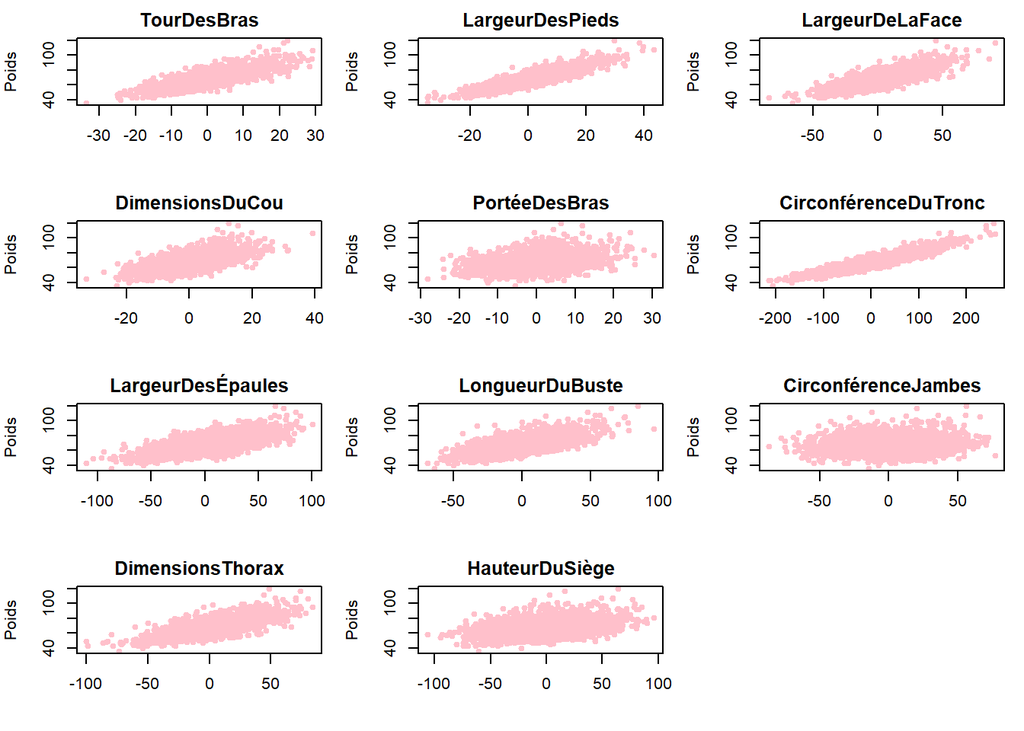

```r
# Femmes
par(mfrow = c(4, 3), mar = c(4, 4, 2, 1))
for (cluster_name in colnames(synthetic_f)) {
  plot(
    synthetic_f[[cluster_name]], Y_f,
    main = cluster_name,
    xlab = "",
    ylab = "Poids",
    col = "pink", pch = 19, cex = 0.7
  )
}
```

# 2 / Sélection de modèle

Pour sélectionner les variables explicatives les plus pertinentes, nous avons commencé par appliquer une réduction automatique via la fonction STEP.

Dans le modèle réduit obtenu, toutes les p-values associées aux coefficients étaient très faibles, indiquant que les variables restantes étaient significatives. Par conséquent, il n’était pas possible d’éliminer d’autres variables sur la base de leur manque de significativité.

Nous avons donc généré toutes les combinaisons possibles de 4 variables issues du modèle réduit et évalué chaque combinaison selon différents critères : SCR, R² ajusté, Cp de Mallow, AIC, BIC et PRESS. Pour analyser ces résultats, nous avons visualisé les valeurs obtenues pour chaque critère sur l’ensemble des combinaisons à l’aide d’histogrammes.

Cependant, le processus devient très long lorsque le nombre de variables augmente. Par exemple, pour sélectionner 4 variables parmi 34, cela implique de tester $\binom{34}{4}$ = 46 376 combinaisons possibles. De plus, le calcul du critère PRESS prend trop de temps car il nécessite n ajustements de modèles en laissant une observation de côté à chaque itération. Du fait de son coût, on a cherché une alternative sur internet, basée sur les leviers de la matrice de projection pour éviter de recalculer le modèle à chaque itération. Voici le site sur lequel on a trouvé la formule : [Statology](https://www.statology.org/press-statistic/)

## 2.1 Hommes

```r
cat("Le modèle initial contient", dim(X_m_reduced)[2], "variables.\n")
```

```
Le modèle initial contient 45 variables.
```

Le modèle initial contient 45 variables.

### 2.1.1 Backward

```r
# Fonctions intermédiaires de calcul du PRESS
calculate_PRESS <- function(model) {
  press <- 0
  data <- model$model
  formula <- formula(model)
  n <- nrow(data)
  for (i in 1:n) {
    train_data <- data[-i, , drop = FALSE]
    test_data <- data[i, , drop = FALSE]
    mod_i <- lm(formula, data = train_data)
    pred <- predict(mod_i, newdata = test_data)
    press <- press + (data[i, 1] - pred)^2
  }
  return(press)
}

calculate_PRESS_fast <- function(model, hat_values) {
  residuals <- residuals(model)
  press <- sum((residuals / (1 - hat_values))^2)
  return(press)
}
```

```r
library(MASS)
library(combinat)

# Modèle initial
full_model <- lm(Y_m ~ ., data = X_m_reduced)

step_model <- step(full_model, direction = "backward", trace = 0)
cat("Le modèle après STEP BACKWARD contient", length(coef(step_model)) - 1, "variables.\n")
```

```
Le modèle après STEP BACKWARD contient 34 variables.
```

```r
variables_candidates <- names(coef(step_model))[-1] # Sans intercept

# Tableau des resultats
results <- data.frame(
  Variables = character(),
  SCR = numeric(),
  R2_adjusted = numeric(),
  Cp_Mallow = numeric(),
  AIC = numeric(),
  BIC = numeric(),
  PRESS = numeric(),
  stringsAsFactors = FALSE
)

combinations <- combn(variables_candidates, 4, simplify = FALSE)

# Teste toutes les combinaisons
for (vars in combinations) {
  formula <- as.formula(paste("Y_m ~", paste(vars, collapse = " + ")))
  model <- lm(formula, data = X_m_reduced)

  n <- length(residuals(model))
  p <- length(coef(model)) - 1

  scr <- sum(residuals(model)^2)
  r2_adj <- summary(model)$adj.r.squared
  sigm <- scr / (n-p-1)
  cp <- scr + 2 * sigm * (p+1)
  hat_values <- hatvalues(model)
  press_val <- calculate_PRESS_fast(model, hat_values)
  aic_val <- n * log(scr/n) + 2 * (p + 1)
  bic_val <- n * log(scr/n) + log(n) * (p + 1)

  results <- rbind(results, data.frame(
    Variables = paste(vars, collapse = ", "),
    SCR = scr,
    R2_adjusted = r2_adj,
    Cp_Mallow = cp,
    AIC = aic_val,
    BIC = bic_val,
    PRESS = press_val
  ))
}

# Sélection meilleur critère
best_aic <- which.min(results$AIC)
best_bic <- which.min(results$BIC)
best_cp <- which.min(results$Cp_Mallow)
best_scr <- which.min(results$SCR)
best_r2_adj <- which.max(results$R2_adjusted)
best_press <- which.min(results$PRESS)

cat("Meilleur modèle selon SCR =", results$SCR[best_scr], "avec les variables :", results$Variables[best_scr], "\n",
  "Meilleur modèle selon R² ajusté =", results$R2_adjusted[best_r2_adj] , "avec les variables :", results$Variables[best_r2_adj], "\n",
  "Meilleur modèle selon Cp de Mallow =", results$Cp_Mallow[best_cp],  "avec les variables :", results$Variables[best_cp], "\n",
  "Meilleur modèle selon AIC =", results$AIC[best_aic], "avec les variables :", results$Variables[best_aic], "\n",
  "Meilleur modèle selon BIC =", results$BIC[best_bic], "avec les variables :", results$Variables[best_bic], "\n",
  "Meilleur modèle selon PRESS =", results$PRESS[best_press], "avec les variables :", results$Variables[best_press], "\n"
)
```

```
Meilleur modèle selon SCR = 35445.93 avec les variables : buttockcircumference, chestdepth, shouldercircumference, wristheight
 Meilleur modèle selon R² ajusté = 0.9570084 avec les variables : buttockcircumference, chestdepth, shouldercircumference, wristheight
 Meilleur modèle selon Cp de Mallow = 35532.87 avec les variables : buttockcircumference, chestdepth, shouldercircumference, wristheight
 Meilleur modèle selon AIC = 8832.922 avec les variables : buttockcircumference, chestdepth, shouldercircumference, wristheight
 Meilleur modèle selon BIC = 8864.493 avec les variables : buttockcircumference, chestdepth, shouldercircumference, wristheight
 Meilleur modèle selon PRESS = 35550.22 avec les variables : buttockcircumference, chestdepth, shouldercircumference, wristheight
```

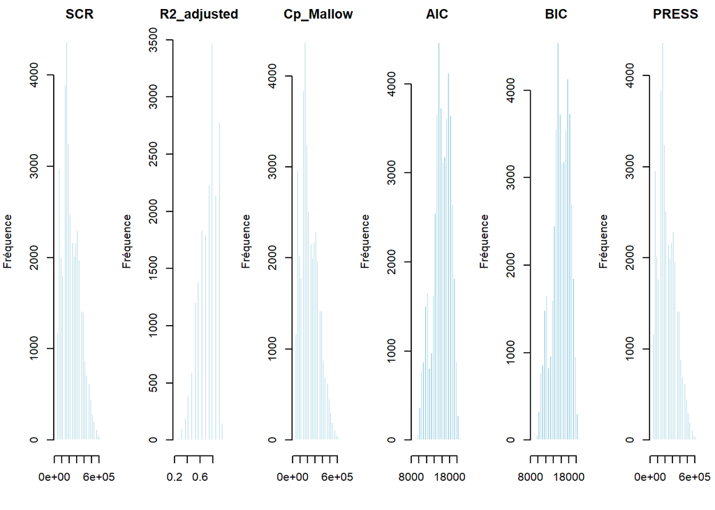

```r
par(mfrow = c(1, 6), mar = c(4, 4, 2, 1))

criteria <- list(
  SCR = best_scr,
  R2_adjusted = best_r2_adj,
  Cp_Mallow = best_cp,
  AIC = best_aic,
  BIC = best_bic,
  PRESS = best_press
)

for (critere in names(criteria)) {
  hist(
    results[[critere]],
    breaks = 30, col = "lightblue", border = "white",
    main = critere,
    xlab = "",
    ylab = "Fréquence"
  )
}
```

### 2.1.2 Forward

```r
# Modèle nul
null_model <- lm(Y_m ~ 1, data = X_m_reduced)
full_model <- lm(Y_m ~ ., data = X_m_reduced)

step_model <- step(null_model,
                   scope = list(lower = null_model, upper = full_model),
                   direction = "forward",
                   test="F",
                   trace = 0)

cat("Le modèle après STEP FORWARD contient", length(coef(step_model)) - 1, "variables.\n")
```

```
Le modèle après STEP FORWARD contient 34 variables.
```

```r
variables_candidates <- names(coef(step_model))[-1] # Sans intercept

results <- data.frame(
  Variables = character(),
  SCR = numeric(),
  R2_adjusted = numeric(),
  Cp_Mallow = numeric(),
  AIC = numeric(),
  BIC = numeric(),
  stringsAsFactors = FALSE
)

combinations <- combn(variables_candidates, 4, simplify = FALSE)

for (vars in combinations) {
  formula <- as.formula(paste("Y_m ~", paste(vars, collapse = " + ")))
  model <- lm(formula, data = X_m_reduced)

  n <- length(residuals(model))
  p <- length(coef(model)) - 1

  scr <- sum(residuals(model)^2)
  r2_adj <- summary(model)$adj.r.squared
  sigm <- scr / (n - p - 1)
  cp <- scr + 2 * sigm * (p + 1)
  aic_val <- n * log(scr / n) + 2 * (p + 1)
  bic_val <- n * log(scr / n) + log(n) * (p + 1)
  hat_values <- hatvalues(model)
  press_val <- calculate_PRESS_fast(model, hat_values)

  results <- rbind(results, data.frame(
    Variables = paste(vars, collapse = ", "),
    SCR = scr,
    R2_adjusted = r2_adj,
    Cp_Mallow = cp,
    AIC = aic_val,
    BIC = bic_val,
    PRESS = press_val

  ))
}

best_aic <- which.min(results$AIC)
best_bic <- which.min(results$BIC)
best_cp <- which.min(results$Cp_Mallow)
best_scr <- which.min(results$SCR)
best_r2_adj <- which.max(results$R2_adjusted)
best_press <- which.min(results$PRESS)

cat("Meilleur modèle selon SCR =", results$SCR[best_scr], "avec les variables :", results$Variables[best_scr], "\n",
  "Meilleur modèle selon R² ajusté =", results$R2_adjusted[best_r2_adj] , "avec les variables :", results$Variables[best_r2_adj], "\n",
  "Meilleur modèle selon Cp de Mallow =", results$Cp_Mallow[best_cp],  "avec les variables :", results$Variables[best_cp], "\n",
  "Meilleur modèle selon AIC =", results$AIC[best_aic], "avec les variables :", results$Variables[best_aic], "\n",
  "Meilleur modèle selon BIC =", results$BIC[best_bic], "avec les variables :", results$Variables[best_bic], "\n",
  "Meilleur modèle selon PRESS =", results$PRESS[best_press], "avec les variables :", results$Variables[best_press], "\n"
)
```

```
Meilleur modèle selon SCR = 35445.93 avec les variables : buttockcircumference, shouldercircumference, wristheight, chestdepth
 Meilleur modèle selon R² ajusté = 0.9570084 avec les variables : buttockcircumference, shouldercircumference, wristheight, chestdepth
 Meilleur modèle selon Cp de Mallow = 35532.87 avec les variables : buttockcircumference, shouldercircumference, wristheight, chestdepth
 Meilleur modèle selon AIC = 8832.922 avec les variables : buttockcircumference, shouldercircumference, wristheight, chestdepth
 Meilleur modèle selon BIC = 8864.493 avec les variables : buttockcircumference, shouldercircumference, wristheight, chestdepth
 Meilleur modèle selon PRESS = 35550.22 avec les variables : buttockcircumference, shouldercircumference, wristheight, chestdepth
```

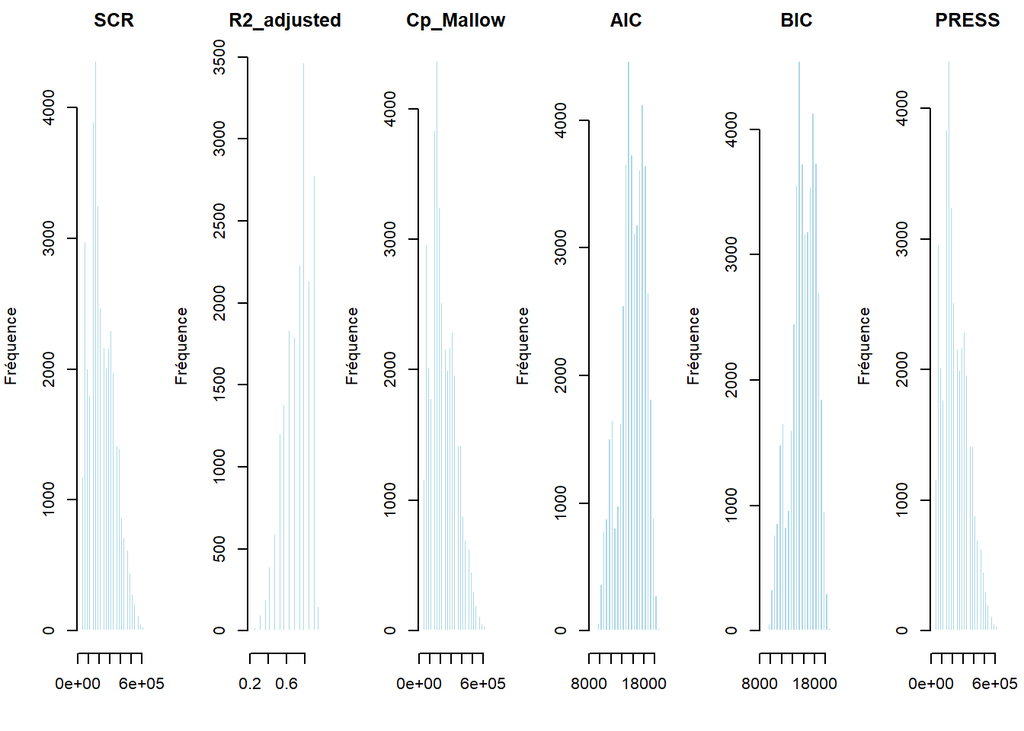

```r
par(mfrow = c(1, 6), mar = c(4, 4, 2, 1))

criteria <- list(
  SCR = best_scr,
  R2_adjusted = best_r2_adj,
  Cp_Mallow = best_cp,
  AIC = best_aic,
  BIC = best_bic,
  PRESS = best_press
)

for (critere in names(criteria)) {
  hist(
    results[[critere]],
    breaks = 30, col = "lightblue", border = "white",
    main = critere,
    xlab = "",
    ylab = "Fréquence"
  )
}
```

## 2.2 Femmes

```r
cat("Le modèle initial contient", dim(X_f_reduced)[2], "variables.\n")
```

```
Le modèle initial contient 44 variables.
```

```r
# Modèle initial
full_model <- lm(Y_f ~ ., data = X_f_reduced)

step_model <- step(full_model, direction = "backward", trace = 0)
cat("Le modèle après STEP BACKWARD contient", length(coef(step_model)) - 1, "variables.\n")
```

```
Le modèle après STEP BACKWARD contient 31 variables.
```

```r
variables_candidates <- names(coef(step_model))[-1] # Sans intercept

# Tableau des resultats
results <- data.frame(
  Variables = character(),
  SCR = numeric(),
  R2_adjusted = numeric(),
  Cp_Mallow = numeric(),
  AIC = numeric(),
  BIC = numeric(),
  PRESS = numeric(),
  stringsAsFactors = FALSE
)

combinations <- combn(variables_candidates, 4, simplify = FALSE)

# Teste toutes les combinaisons
for (vars in combinations) {
  formula <- as.formula(paste("Y_f ~", paste(vars, collapse = " + ")))
  model <- lm(formula, data = X_f_reduced)

  n <- length(residuals(model))
  p <- length(coef(model)) - 1

  scr <- sum(residuals(model)^2)
  r2_adj <- summary(model)$adj.r.squared
  sigm <- scr / (n-p-1)
  cp <- scr + 2 * sigm * (p+1)
  hat_values <- hatvalues(model)
  press_val <- calculate_PRESS_fast(model, hat_values)
  aic_val <- n * log(scr/n) + 2 * (p + 1)
  bic_val <- n * log(scr/n) + log(n) * (p + 1)

  results <- rbind(results, data.frame(
    Variables = paste(vars, collapse = ", "),
    SCR = scr,
    R2_adjusted = r2_adj,
    Cp_Mallow = cp,
    AIC = aic_val,
    BIC = bic_val,
    PRESS = press_val
  ))
}

# Sélection meilleur critère
best_aic <- which.min(results$AIC)
best_bic <- which.min(results$BIC)
best_cp <- which.min(results$Cp_Mallow)
best_scr <- which.min(results$SCR)
best_r2_adj <- which.max(results$R2_adjusted)
best_press <- which.min(results$PRESS)

cat("Meilleur modèle selon SCR =", results$SCR[best_scr], "avec les variables :", results$Variables[best_scr], "\n",
  "Meilleur modèle selon R² ajusté =", results$R2_adjusted[best_r2_adj] , "avec les variables :", results$Variables[best_r2_adj], "\n",
  "Meilleur modèle selon Cp de Mallow =", results$Cp_Mallow[best_cp],  "avec les variables :", results$Variables[best_cp], "\n",
  "Meilleur modèle selon AIC =", results$AIC[best_aic], "avec les variables :", results$Variables[best_aic], "\n",
  "Meilleur modèle selon BIC =", results$BIC[best_bic], "avec les variables :", results$Variables[best_bic], "\n",
  "Meilleur modèle selon PRESS =", results$PRESS[best_press], "avec les variables :", results$Variables[best_press], "\n"
)
```

```
Meilleur modèle selon SCR = 12757.75 avec les variables : buttockcircumference, calfcircumference, chestdepth, sleevelengthspinewrist
 Meilleur modèle selon R² ajusté = 0.9466275 avec les variables : buttockcircumference, calfcircumference, chestdepth, sleevelengthspinewrist
 Meilleur modèle selon Cp de Mallow = 12822.15 avec les variables : buttockcircumference, calfcircumference, chestdepth, sleevelengthspinewrist
 Meilleur modèle selon AIC = 3703.992 avec les variables : buttockcircumference, calfcircumference, chestdepth, sleevelengthspinewrist
 Meilleur modèle selon BIC = 3731.962 avec les variables : buttockcircumference, calfcircumference, chestdepth, sleevelengthspinewrist
 Meilleur modèle selon PRESS = 12836.4 avec les variables : buttockcircumference, calfcircumference, chestdepth, sleevelengthspinewrist
```

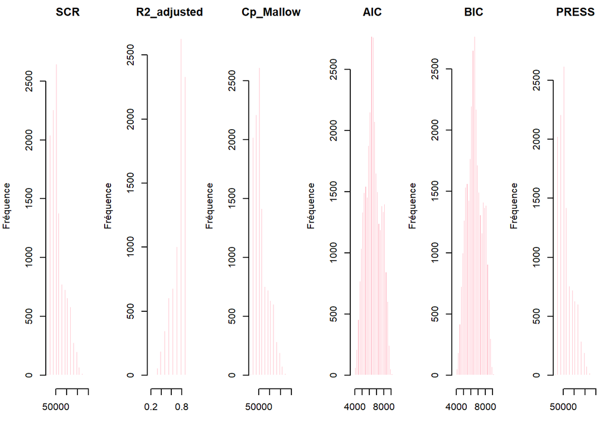

```r
par(mfrow = c(1, 6), mar = c(4, 4, 2, 1))

criteria <- list(
  SCR = best_scr,
  R2_adjusted = best_r2_adj,
  Cp_Mallow = best_cp,
  AIC = best_aic,
  BIC = best_bic,
  PRESS = best_press
)

for (critere in names(criteria)) {
  hist(
    results[[critere]],
    breaks = 30, col = "pink", border = "white",
    main = critere,
    xlab = "",
    ylab = "Fréquence"
  )
}
```

```r
# Modèle nul
null_model <- lm(Y_f ~ 1, data = X_f_reduced)
full_model <- lm(Y_f ~ ., data = X_f_reduced)

step_model <- step(null_model,
                   scope = list(lower = null_model, upper = full_model),
                   direction = "forward",
                   test="F",
                   trace = 0)

cat("Le modèle après STEP FORWARD contient", length(coef(step_model)) - 1, "variables.\n")
```

```
Le modèle après STEP FORWARD contient 29 variables.
```

```r
variables_candidates <- names(coef(step_model))[-1] # Sans intercept

results <- data.frame(
  Variables = character(),
  SCR = numeric(),
  R2_adjusted = numeric(),
  Cp_Mallow = numeric(),
  AIC = numeric(),
  BIC = numeric(),
  PRESS = numeric(),
  stringsAsFactors = FALSE
)

combinations <- combn(variables_candidates, 4, simplify = FALSE)

for (vars in combinations) {
  formula <- as.formula(paste("Y_f ~", paste(vars, collapse = " + ")))
  model <- lm(formula, data = X_f_reduced)

  n <- length(residuals(model))
  p <- length(coef(model)) - 1

  scr <- sum(residuals(model)^2)
  r2_adj <- summary(model)$adj.r.squared
  sigm <- scr / (n - p - 1)
  cp <- scr + 2 * sigm * (p + 1)
  hat_values <- hatvalues(model)
  press_val <- calculate_PRESS_fast(model, hat_values)
  aic_val <- n * log(scr / n) + 2 * (p + 1)
  bic_val <- n * log(scr / n) + log(n) * (p + 1)

  results <- rbind(results, data.frame(
    Variables = paste(vars, collapse = ", "),
    SCR = scr,
    R2_adjusted = r2_adj,
    Cp_Mallow = cp,
    AIC = aic_val,
    BIC = bic_val,
    PRESS = press_val
  ))
}

best_aic <- which.min(results$AIC)
best_bic <- which.min(results$BIC)
best_cp <- which.min(results$Cp_Mallow)
best_scr <- which.min(results$SCR)
best_r2_adj <- which.max(results$R2_adjusted)
best_press <- which.min(results$PRESS)

cat("Meilleur modèle selon SCR =", results$SCR[best_scr], "avec les variables :", results$Variables[best_scr], "\n",
  "Meilleur modèle selon R² ajusté =", results$R2_adjusted[best_r2_adj] , "avec les variables :", results$Variables[best_r2_adj], "\n",
  "Meilleur modèle selon Cp de Mallow =", results$Cp_Mallow[best_cp],  "avec les variables :", results$Variables[best_cp], "\n",
  "Meilleur modèle selon AIC =", results$AIC[best_aic], "avec les variables :", results$Variables[best_aic], "\n",
  "Meilleur modèle selon BIC =", results$BIC[best_bic], "avec les variables :", results$Variables[best_bic], "\n",
  "Meilleur modèle selon PRESS =", results$PRESS[best_press], "avec les variables :", results$Variables[best_press], "\n"
)
```

```
Meilleur modèle selon SCR = 12757.75 avec les variables : buttockcircumference, chestdepth, calfcircumference, sleevelengthspinewrist
 Meilleur modèle selon R² ajusté = 0.9466275 avec les variables : buttockcircumference, chestdepth, calfcircumference, sleevelengthspinewrist
 Meilleur modèle selon Cp de Mallow = 12822.15 avec les variables : buttockcircumference, chestdepth, calfcircumference, sleevelengthspinewrist
 Meilleur modèle selon AIC = 3703.992 avec les variables : buttockcircumference, chestdepth, calfcircumference, sleevelengthspinewrist
 Meilleur modèle selon BIC = 3731.962 avec les variables : buttockcircumference, chestdepth, calfcircumference, sleevelengthspinewrist
 Meilleur modèle selon PRESS = 12836.4 avec les variables : buttockcircumference, chestdepth, calfcircumference, sleevelengthspinewrist
```

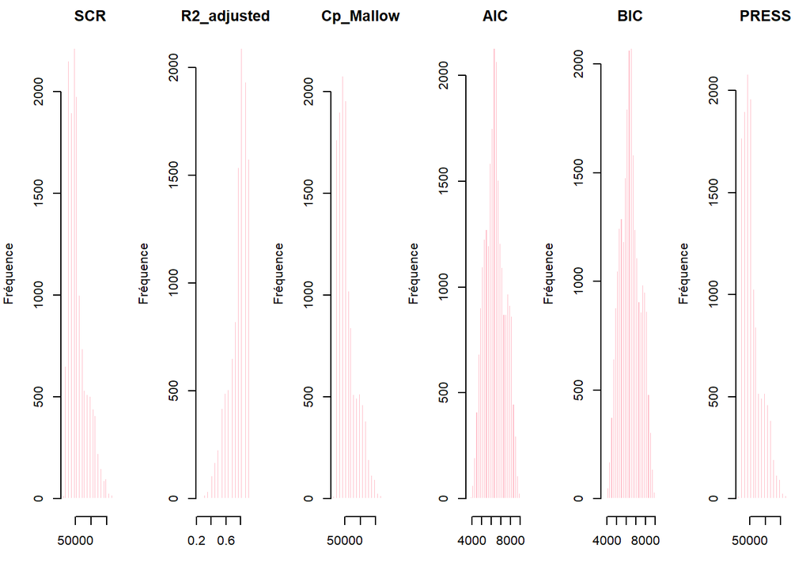

```r
par(mfrow = c(1, 6), mar = c(4, 4, 2, 1))

criteria <- list(
  SCR = best_scr,
  R2_adjusted = best_r2_adj,
  Cp_Mallow = best_cp,
  AIC = best_aic,
  BIC = best_bic,
  PRESS = best_press
)

for (critere in names(criteria)) {
  hist(
    results[[critere]],
    breaks = 30, col = "pink", border = "white",
    main = critere,
    xlab = "",
    ylab = "Fréquence"
  )
}
```

### Conclusion

Pour aller plus loin, on pourrait utiliser une méthode heuristique, comme vu l’année dernière en cours de Techniques Algorithmiques, pour réduire le nombre de combinaisons à tester. L’algo, en s’approchant séquentiellement de la solution optimale, permettrait d’éviter l’exploration exhaustive des combinaisons inutiles?